# URL Phishing :

## C'est quoi un URL ?

**Compositions de l'Uniform Resource Locator (URL) : protocole, nom d'hôte (domaine principal + domaine de premier niveau), et enfin le chemin.**

-Mon objectif initial est de comprendre en profondeur les données de ma base de données URL (phishing, non phishing) et de me familiariser avec leur structure.

-Plus spécifiquement, je cherche à préparer et à réfléchir à la tokenisation des URL. La tokenisation implique de découper les URL en éléments distincts, tels que le protocole, le nom d'hôte et le chemin, afin de les transformer en vecteurs numériques exploitables par mes modèles de machine learning.

-En outre, je prévois de caractériser les URL en analysant différentes caractéristiques telles que la présence d'adresses IP, l'utilisation de mots-clés associés aux transactions financières, etc. Cette caractérisation me permettra de mieux comprendre le comportement des URL et d'identifier les tendances ou les schémas récurrents.

-Pour atteindre ces objectifs, je prévois d'effectuer des statistiques descriptives sur ma base de données d'URL. Cela me permettra d'obtenir une meilleure visibilité sur la distribution des différentes caractéristiques des URL et de décortiquer les données en fonction des besoins spécifiques mentionnés dans l'énoncé de la demande.

-En résumé, je souhaite explorer et analyser en profondeur les données des URL en les transformant en vecteurs numériques, en caractérisant leurs différents aspects et en effectuant des analyses statistiques détaillées. Ces étapes préliminaires sont essentielles pour préparer mes données avant de les utiliser dans mes modèles de machine learning.

[figure not shown]

### Remarque d'avant propos :

Selon l'énoncé du problème et mon intuition, je vais me concentrer sur trois modèles : XGBoost, LightGBM et Random Forest. Je considère également l'utilisation de la régression logistique, car elle est simple et efficace, bien que peut-être moins adaptée à un grand nombre de données. Je souhaite l'inclure surtout parce que c'est une méthode qui peut être intégrée à d'autres méthodes. Quant au stacking, je verrais cela par la suite.

Pour la visualisation, j'envisage d'utiliser des nuages de mots (wordcloud) et la bibliothèque Seaborn.

# Sommaire

## 1-Prétraitement des URLs

## 2-Extraction de caractéristiques ( feature enineering)

## 3-Entraînements, Validations, Evalutions

## 4-Analyse des résultats, Optimisation

## 5-Stacking

## 6-La mise en production

## 7-Pour aller plus loin : Transformers ?

## 1-Prétraitement des URLs :

```python
#importation des bibitheques python importantes pour le traitement des URl's
#pandas pour les data frame, les modeles et techniques, metrics de classifiction, ..
import pandas as pd
import itertools
from sklearn.metrics import classification_report,confusion_matrix, accuracy_score
from sklearn.model_selection import train_test_split
import pandas as pd
import numpy as np
import matplotlib.pyplot as plt
import xgboost as xgb
from lightgbm import LGBMClassifier
import os
import seaborn as sns
from wordcloud import WordCloud
```

```python
#mise en place du repertoire de travail

import os
repertoire_travail = os.getcwd()
print("Répertoire de travail actuel :", repertoire_travail)
```

```
Répertoire de travail actuel : C:\Users\toumani.a\Downloads
```

```python
#data load

df=pd.read_csv('dataset.csv')

print(df.shape)
df.head()
```

```
(120990, 2)
```

|  | domain | label |
| --- | --- | --- |
| 0 | http://sprint.com/business/solutions/mobility_... | 0.0 |
| 1 | hesperia.gsfc.nasa.gov/~schmahl/nnls/ | 0.0 |
| 2 | http://web.de/magazine/digital/sicher-im-netz/... | 0.0 |
| 3 | www.wired.com/science/discoveries/news/1999/08... | 0.0 |
| 4 | thomas.arnatt.com/wp-includes/pono/AOL_Logio.htm | 1.0 |

```python
#je suis alaise avec les termes URL et type

# Renommer les colonnes "domain" et "label" en "url" et "type"
df = df.rename(columns={'domain': 'url', 'label': 'type'})

# Vérifier que les noms de colonnes ont été changés
print(df.columns)
```

[output not shown]

```python
#sommaire
df.type.value_counts()
```

```
0.0    92680
1.0    28310
Name: type, dtype: int64
```

```python
#shape
print(df.shape)
df.head()
```

```
(120990, 2)
```

|  | url | type |
| --- | --- | --- |
| 0 | http://sprint.com/business/solutions/mobility_... | 0.0 |
| 1 | hesperia.gsfc.nasa.gov/~schmahl/nnls/ | 0.0 |
| 2 | http://web.de/magazine/digital/sicher-im-netz/... | 0.0 |
| 3 | www.wired.com/science/discoveries/news/1999/08... | 0.0 |
| 4 | thomas.arnatt.com/wp-includes/pono/AOL_Logio.htm | 1.0 |

## Plotting Wordcloud

```python
#visualisation des URL normal et phishing
df_phish = df[df.type == 1.0]
df_begnin = df[df.type == 0.0]
```

```python
print(df_phish.head())
```

```
                                                  url  type
4    thomas.arnatt.com/wp-includes/pono/AOL_Logio.htm   1.0
10  ghislainebutel.dom/img/common/visa.dk/update-a...   1.0
11                  pastehtml.com/view/bdvepdyhi.html   1.0
12  update-informationt019.creativeplaytiings.com....   1.0
19  dhriscel.com/uwbnzwyrcT1epmk19617/g53fwse7hjTx...   1.0
```

### Phishing

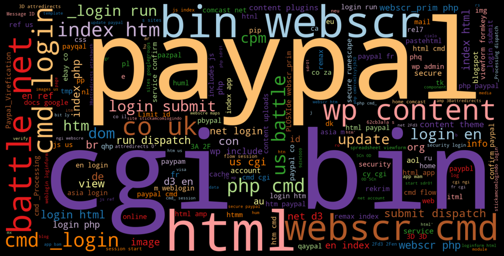

```python
# Accéder à la colonne "url" et concaténer les valeurs
phish_url = " ".join(str(i) for i in df_phish['url'])

# Générer le nuage de mots
wordcloud = WordCloud(width=1600, height=800, colormap='Paired').generate(phish_url)

# Afficher le nuage de mots
plt.figure(figsize=(12, 14), facecolor='k')
plt.imshow(wordcloud, interpolation='bilinear')
plt.axis("off")
plt.tight_layout(pad=0)
plt.show()
```

### URL safe

```python
## confirme mon appiori sur les mots suspects financiers dans les URL phishing
```

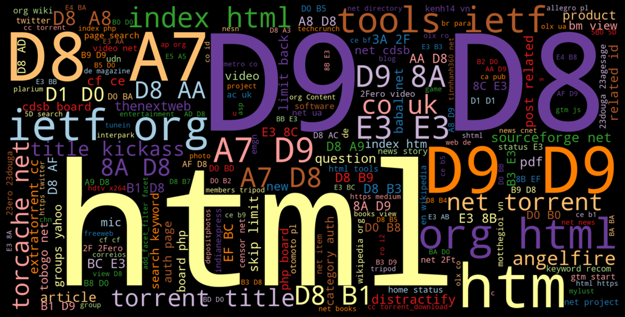

```python
begnin_url = " ".join(i for i in df_begnin.url)
wordcloud = WordCloud(width=1600, height=800,colormap='Paired').generate(begnin_url)
plt.figure( figsize=(12,14),facecolor='k')
plt.imshow(wordcloud, interpolation='bilinear')
plt.axis("off")
plt.tight_layout(pad=0)
plt.show()
```

```python
#commentaire : les mots les plus accurantes dans des deux visuelles,
#je mets les mots de coté en attendant que je visualise la distrubution des features que vais crée
```

**Pour le prétraitement des URL, j'ai plusieurs options en tête, telles que l'élimination des caractères spéciaux, des espaces, des balises, la normalisation des URL, la tokenisation, etc. J'ai choisi de ne pas effectuer tous ces changements dans un premier temps, car je n'ai pas encore suffisamment de recul sur ce qui est pertinent ou non pour la classification à l'instant t. Je choisis de conserver le format des URL tel quel.**

## 2-Feature Engineering

```python
#dans cette partie nous allons : Identifie les caractéristiques les plus pertinentes pour le problème en éliminant les caractéristiques redondantes ou peu informatives.
#premiére etape est de voir es que oui ou non l'url contient des ip
```

```python
# je vais crée un fonction qui va créer une nouvelle colonne
#binaire qui nous donnera 1 si il ya une adresse IP, 0 sinon
```

Dans cette partie, nous allons identifier les caractéristiques les plus pertinentes pour le problème en éliminant les caractéristiques redondantes ou peu informatives. La première étape consiste à vérifier si l'URL contient des adresses IP. Nous utiliserons le module re (expressions régulières) pour rechercher la présence d'une adresse IP dans l'URL.

```python
import re
#Use of IP or not in domain
def having_ip_address(url):
    match = re.search(
        '(([01]?\\d\\d?|2[0-4]\\d|25[0-5])\\.([01]?\\d\\d?|2[0-4]\\d|25[0-5])\\.([01]?\\d\\d?|2[0-4]\\d|25[0-5])\\.'
        '([01]?\\d\\d?|2[0-4]\\d|25[0-5])\\/)|'  # IPv4
        '((0x[0-9a-fA-F]{1,2})\\.(0x[0-9a-fA-F]{1,2})\\.(0x[0-9a-fA-F]{1,2})\\.(0x[0-9a-fA-F]{1,2})\\/)' # IPv4 in hexadecimal
        '(?:[a-fA-F0-9]{1,4}:){7}[a-fA-F0-9]{1,4}', url)  # Ipv6
    if match:
        # print match.group()
        return 1
    else:
        # print 'No matching pattern found'
        return 0
df['use_of_ip'] = df['url'].apply(lambda i: having_ip_address(i))
```

```python
# je vise à détecter les URL anormales en vérifiant si le nom d'hôte (hostname) de l'URL est répété dans l'URL elle-même
```

```python
from urllib.parse import urlparse

def abnormal_url(url):
    hostname = urlparse(url).hostname
    hostname = str(hostname)
    match = re.search(hostname, url)
    if match:
        # print match.group()
        return 1
    else:
        # print 'No matching pattern found'
        return 0


df['abnormal_url'] = df['url'].apply(lambda i: abnormal_url(i))
```

```python
## ici dans le code je vais chercher les url qui proviennet de google ou pas
```

```python
pip install googlesearch-python
```

```python
from googlesearch import search
```

```python
def google_index(url):
    site = search(url, 5)
    return 1 if site else 0
df['google_index'] = df['url'].apply(lambda i: google_index(i))
```

```python
# ici meme proceder, je cherche et je compte le nb de (.) dans les URL et mettre ca dans une colonne
```

```python
def count_dot(url):
    count_dot = url.count('.')
    return count_dot

df['count.'] = df['url'].apply(lambda i: count_dot(i))
df.head()
```

[output not shown]

```python
# ici je vais compter pour chaque URL le nb de fois que le (www) et mettre ca dans une colonne
# pareil pour (@, /, //), pour chaque element je crée une colonne
# j'ai mis en place la fonction def shortening_service(url), pour discriminer les URL
```

```python
# je crée la variable short url, parce que d'apres la visualisation la longueur du URL est pertinante dans la classification d'URl safe ou pas
```

```python
def count_www(url):
    url.count('www')
    return url.count('www')

df['count-www'] = df['url'].apply(lambda i: count_www(i))

def count_atrate(url):

    return url.count('@')

df['count@'] = df['url'].apply(lambda i: count_atrate(i))


def no_of_dir(url):
    urldir = urlparse(url).path
    return urldir.count('/')

df['count_dir'] = df['url'].apply(lambda i: no_of_dir(i))

def no_of_embed(url):
    urldir = urlparse(url).path
    return urldir.count('//')

df['count_embed_domian'] = df['url'].apply(lambda i: no_of_embed(i))


def shortening_service(url):
    match = re.search('bit\.ly|goo\.gl|shorte\.st|go2l\.ink|x\.co|ow\.ly|t\.co|tinyurl|tr\.im|is\.gd|cli\.gs|'
                      'yfrog\.com|migre\.me|ff\.im|tiny\.cc|url4\.eu|twit\.ac|su\.pr|twurl\.nl|snipurl\.com|'
                      'short\.to|BudURL\.com|ping\.fm|post\.ly|Just\.as|bkite\.com|snipr\.com|fic\.kr|loopt\.us|'
                      'doiop\.com|short\.ie|kl\.am|wp\.me|rubyurl\.com|om\.ly|to\.ly|bit\.do|t\.co|lnkd\.in|'
                      'db\.tt|qr\.ae|adf\.ly|goo\.gl|bitly\.com|cur\.lv|tinyurl\.com|ow\.ly|bit\.ly|ity\.im|'
                      'q\.gs|is\.gd|po\.st|bc\.vc|twitthis\.com|u\.to|j\.mp|buzurl\.com|cutt\.us|u\.bb|yourls\.org|'
                      'x\.co|prettylinkpro\.com|scrnch\.me|filoops\.info|vzturl\.com|qr\.net|1url\.com|tweez\.me|v\.gd|'
                      'tr\.im|link\.zip\.net',
                      url)
    if match:
        return 1
    else:
        return 0

## faire une visualisation sur les resultats :

df['short_url'] = df['url'].apply(lambda i: shortening_service(i))
```

```python
# je compte les https
```

```python
def count_https(url):
    return url.count('https')

df['count-https'] = df['url'].apply(lambda i : count_https(i))

def count_http(url):
    return url.count('http')

df['count-http'] = df['url'].apply(lambda i : count_http(i))
```

Caractères spéciaux (% ? = -), cela rejoint ma strategie de laisser les URL afin de conserver le maximum d'informations possible. Ces caractères sont importants dans les URL. J'ai également créé d'autres variables (colonnes) que je juge pertinentes, telles que la taille des URL, la taille des noms d'hôte, etc.

Enfin, la dernière variable créée est une fonction appelée "mots suspects", basée sur les mots-clés relevés dans le nuage de mots des URL de phishing mentionné précédemment.

```python
# faire atgtention en majuscule et minuscule:
def count_per(url):
    return url.count('%')

df['count%'] = df['url'].apply(lambda i : count_per(i))

def count_ques(url):
    return url.count('?')

df['count?'] = df['url'].apply(lambda i: count_ques(i))

def count_hyphen(url):
    return url.count('-')

df['count-'] = df['url'].apply(lambda i: count_hyphen(i))

def count_equal(url):
    return url.count('=')

df['count='] = df['url'].apply(lambda i: count_equal(i))

def url_length(url):
    return len(str(url))


#Length of URL
df['url_length'] = df['url'].apply(lambda i: url_length(i))
#Hostname Length

def hostname_length(url):
    return len(urlparse(url).netloc)

df['hostname_length'] = df['url'].apply(lambda i: hostname_length(i))

df.head()

def suspicious_words(url):
    match = re.search('PayPal|login|signin|bank|account|update|free|cgi|bin|bonus|ebayisapi|battle web',
                      url)
    if match:
        return 1
    else:
        return 0
df['sus_url'] = df['url'].apply(lambda i: suspicious_words(i))


def digit_count(url):
    digits = 0
    for i in url:
        if i.isnumeric():
            digits = digits + 1
    return digits


df['count-digits']= df['url'].apply(lambda i: digit_count(i))


def letter_count(url):
    letters = 0
    for i in url:
        if i.isalpha():
            letters = letters + 1
    return letters


df['count-letters']= df['url'].apply(lambda i: letter_count(i))

df.head()
```

|  | url | type | use_of_ip | abnormal_url | count. | count-www | count@ | count_dir | count_embed_domian | short_url | ... | count-http | count% | count? | count- | count= | url_length | hostname_length | sus_url | count-digits | count-letters |
| --- | --- | --- | --- | --- | --- | --- | --- | --- | --- | --- | --- | --- | --- | --- | --- | --- | --- | --- | --- | --- | --- |
| 0 | http://sprint.com/business/solutions/mobility_... | 0.0 | 0 | 1 | 2 | 0 | 0 | 4 | 0 | 1 | ... | 1 | 0 | 1 | 0 | 1 | 105 | 10 | 0 | 0 | 89 |
| 1 | hesperia.gsfc.nasa.gov/~schmahl/nnls/ | 0.0 | 0 | 0 | 3 | 0 | 0 | 3 | 0 | 0 | ... | 0 | 0 | 0 | 0 | 0 | 37 | 0 | 0 | 0 | 30 |
| 2 | http://web.de/magazine/digital/sicher-im-netz/... | 0.0 | 0 | 1 | 1 | 0 | 0 | 4 | 0 | 0 | ... | 1 | 0 | 0 | 10 | 0 | 131 | 6 | 0 | 8 | 105 |
| 3 | www.wired.com/science/discoveries/news/1999/08... | 0.0 | 0 | 0 | 2 | 1 | 0 | 6 | 0 | 0 | ... | 0 | 0 | 0 | 0 | 0 | 52 | 0 | 0 | 11 | 33 |
| 4 | thomas.arnatt.com/wp-includes/pono/AOL_Logio.htm | 1.0 | 0 | 0 | 3 | 0 | 0 | 3 | 0 | 1 | ... | 0 | 0 | 0 | 1 | 0 | 48 | 0 | 0 | 0 | 40 |

5 rows × 21 columns

```python
#!pip install tld
```

```python
##Top-Level Domain,code qui extrait la longueur du premier répertoire dans le chemin de chaque URL, ainsi que la longueur du TLD de chaque URL, et stocke ces informations
#dans de nouvelles colonnes du DataFrame
```

```python
#Importing dependencies
from urllib.parse import urlparse
from tld import get_tld
import os.path

#First Directory Length
def fd_length(url):
    urlpath= urlparse(url).path
    try:
        return len(urlpath.split('/')[1])
    except:
        return 0

df['fd_length'] = df['url'].apply(lambda i: fd_length(i))

#Length of Top Level Domain
df['tld'] = df['url'].apply(lambda i: get_tld(i,fail_silently=True))


def tld_length(tld):
    try:
        return len(tld)
    except:
        return -1

df['tld_length'] = df['tld'].apply(lambda i: tld_length(i))
```

```python
# je retire cette varible apres avoir calculer la longueur, c'est un feature non numeric
```

```python
df = df.drop("tld",1)
```

```python
df.columns
```

```
Index(['url', 'type', 'use_of_ip', 'abnormal_url', 'google_index', 'count.',
       'count-www', 'count@', 'count_dir', 'count_embed_domian', 'short_url',
       'count-https', 'count-http', 'count%', 'count?', 'count-', 'count=',
       'url_length', 'hostname_length', 'sus_url', 'count-digits',
       'count-letters', 'fd_length', 'tld_length'],
      dtype='object')
```

```python
# dans la suite je vais enlever la variable URL apres avoir crée tous les features
```

```python
df['type'].value_counts()
```

```
0.0    92680
1.0    28310
Name: type, dtype: int64
```